# Starcraft Skill Data - Exploration

Linear Regression Model Selection

Sergei Dakov

2023-07-19

The linear regression model is used in this case a quick and basic comparison baseline. To avoid claims of an unfair comparison we will perform the same model selection steps as all other models, thus giving the LR model a “fair chance”

# Data Preparation

Before we start, we load in required packages:

```r
library(tidyverse) # library containing tools for streamlining and tidying data processing
library(rsample) #library for sampling and data splitting
library(naniar) #library for visualization of missing data
library(parsnip) #library for tidy model construction
library(recipes) #library to easier manipulate data for model construction
library(themis) #library for dealing with imbalances with artificial sampling
library(yardstick) #functions o calculate metrics
library(tune) #library that allows to tune multiple parameters at once
```

Next, load in some helper functions:

```r
source("model_selection_skeleton.r")
```

Finally, we load in the data:

```r
skillData <- read_csv("SkillCraft1_Dataset.csv") %>%
  mutate(LeagueIndex = factor(LeagueIndex)) %>%
  select(-c("Age","HoursPerWeek","TotalHours","GameID")) %>%
  mutate(LeagueIndex = as.numeric(LeagueIndex))
```

Perform the initial split:

```r
set.seed(1234)
reg_split <- initial_split(skillData,strata = "LeagueIndex")
regression_train <- training(reg_split)
regression_test <- testing(reg_split)
```

As a baseline we use a simple LR model and get a prediction, and relevant metrics for this case. Note that the linear regression model is likley to provide a non whole value thus we need to round the values

```r
mod_glm <- glm(LeagueIndex~.,data=regression_train)
predicted_guess <- predict(mod_glm,regression_test) %>% round()
regression_test_round <- regression_test %>% cbind(guess = predicted_guess)
regression_test_round  %>% mutate(hit = ifelse(guess==LeagueIndex,1,0)) %>% pull(hit) -> hits
mean(hits)
```

```
## [1] 0.3976471
```

```r
OnevRest(regression_test_round,truth = "LeagueIndex",guess = "guess")
```

```
## [1] 0.6083192
```

The AUC is 0.61, and accuracy of the model is 0.397.

Since there are multiple ways to round a number, we can test multiple cutoff points, and select the best performing one.

```r
predicted_guess <- predict(mod_glm,regression_test)
results <- numeric()
results_means <- numeric()
for (i in seq(0,1,by=0.001)) {
predicted_cut <- cutoff(predicted_guess,i)
regression_test_cut <- regression_test %>% cbind(guess = predicted_cut)
regression_test_cut  %>% mutate(hit = ifelse(guess==LeagueIndex,1,0)) %>% pull(hit) -> hits
results<-c(results,OnevRest(regression_test_round,truth = "LeagueIndex",guess = "guess"))
results_means <- c(results_means,mean(hits))
}
max(results)
```

```
## [1] 0.6083192
```

```r
(which.max(results)-1)*0.001
```

```
## [1] 0
```

```r
max(results_means)
```

```
## [1] 0.4105882
```

```r
(which.max(results_means)-1)*0.001
```

```
## [1] 0.354
```

For the AUC, all cutoffs offer the same degree of separation, thus we look to accuracy as a secondary measure. In this case the best cutoff is at 0.354, with an accuracy of 0.411.

# Model Selection

First, we need to re load the data, as we omitted some columns in the naive model:

```r
skillData <- read_csv("SkillCraft1_Dataset.csv") %>%
  select(-Age) %>%
  mutate(across(c("HoursPerWeek","TotalHours"),~as.numeric(.x)))
glimpse(skillData)
```

```
## Rows: 3,395
## Columns: 19
## $ GameID               <dbl> 52, 55, 56, 57, 58, 60, 61, 72, 77, 81, 83, 93, 9…
## $ LeagueIndex          <dbl> 5, 5, 4, 3, 3, 2, 1, 7, 4, 4, 3, 4, 3, 3, 5, 5, 4…
## $ HoursPerWeek         <dbl> 10, 10, 10, 20, 10, 6, 8, 42, 14, 24, 16, 4, 12, …
## $ TotalHours           <dbl> 3000, 5000, 200, 400, 500, 70, 240, 10000, 2708, …
## $ APM                  <dbl> 143.7180, 129.2322, 69.9612, 107.6016, 122.8908, …
## $ SelectByHotkeys      <dbl> 0.0035151591, 0.0033038124, 0.0011010906, 0.00103…
## $ AssignToHotkeys      <dbl> 2.196974e-04, 2.594617e-04, 3.355705e-04, 2.13101…
## $ UniqueHotkeys        <dbl> 7, 4, 4, 1, 2, 2, 6, 6, 2, 8, 4, 3, 1, 2, 2, 4, 1…
## $ MinimapAttacks       <dbl> 1.098487e-04, 2.940566e-04, 2.936242e-04, 5.32753…
## $ MinimapRightClicks   <dbl> 3.923169e-04, 4.324362e-04, 4.614094e-04, 5.43408…
## $ NumberOfPACs         <dbl> 0.004849036, 0.004307064, 0.002925755, 0.00378255…
## $ GapBetweenPACs       <dbl> 32.6677, 32.9194, 44.6475, 29.2203, 22.6885, 76.4…
## $ ActionLatency        <dbl> 40.8673, 42.3454, 75.3548, 53.7352, 62.0813, 98.7…
## $ ActionsInPAC         <dbl> 4.7508, 4.8434, 4.0430, 4.9155, 9.3740, 3.0965, 4…
## $ TotalMapExplored     <dbl> 28, 22, 22, 19, 15, 16, 15, 45, 29, 27, 24, 19, 1…
## $ WorkersMade          <dbl> 0.00139660, 0.00119350, 0.00074455, 0.00042620, 0…
## $ UniqueUnitsMade      <dbl> 6, 5, 6, 7, 4, 6, 5, 9, 7, 6, 7, 7, 7, 5, 7, 6, 6…
## $ ComplexUnitsMade     <dbl> 0.000000e+00, 0.000000e+00, 0.000000e+00, 0.00000…
## $ ComplexAbilitiesUsed <dbl> 0.0000e+00, 2.0757e-04, 1.8876e-04, 3.8358e-04, 1…
```

```r
#New initial split
set.seed(1234)
reg_split <- initial_split(skillData,strata = "LeagueIndex")
regression_train <- training(reg_split)
regression_test <- testing(reg_split)

mod_reg <- linear_reg(engine = "glmnet",penalty = 0.01)
```

-imbalance: 800

-missing Values: 445

-interactions: 1000

-hyper Parameters: 300

NOTE: many of the numeric variables are not normally distributed, we may apply the BoxCox transformation to normalize them, though log transform appears to be enough for some.

```r
split_sizes <- c("imbalance"=800,"interactions"=1000,"tuning"=300,"missing"=445)


set.seed(1234)
miss_split <- initial_split(regression_train,strata = "LeagueIndex",prop = (split_sizes["missing"]+2)/nrow(regression_train))
train_miss <- training(miss_split)
rest_split <- testing(miss_split)

set.seed(1234)
interaction_split <- initial_split(rest_split,strata="LeagueIndex",prop = ((split_sizes["interactions"])/nrow(rest_split)))
train_interaction <- training(interaction_split)
rest_split <- testing(interaction_split)

set.seed(1234)
imbalance_split <- initial_split(rest_split,strata="LeagueIndex",prop = ((split_sizes["imbalance"]+1)/nrow(rest_split)))
train_imbalance <- training(imbalance_split)
train_tuning <- testing(imbalance_split)
```

# Missing Values

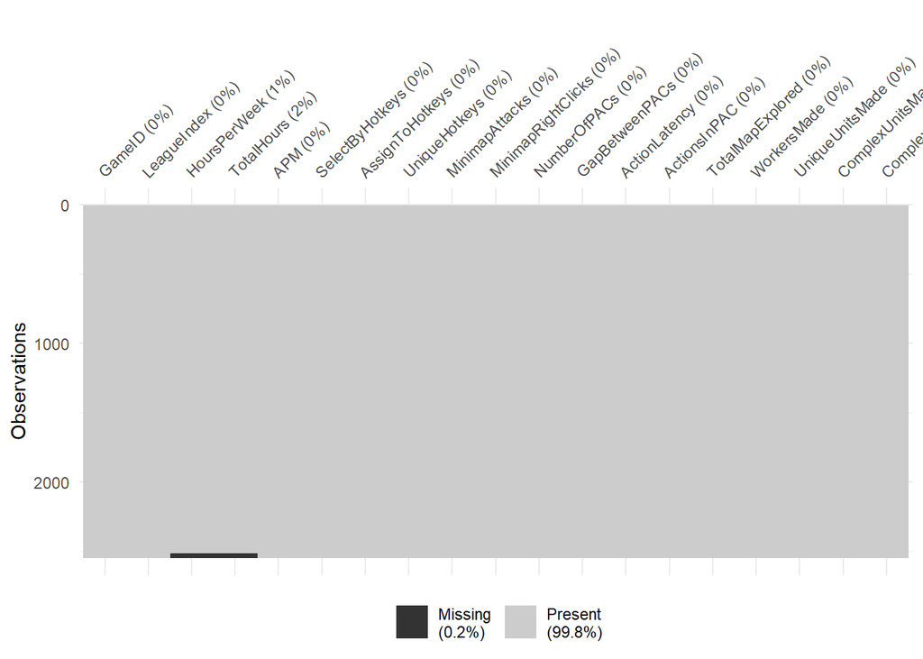

```r
vis_miss(regression_train)
```

The main missing values come from one category- pro players, but not entirely.

We could just assume each data point with missing data is a pro and drop the missing values or use it as an extra variable to help direct the model.

```r
# substitute the mean values in place of NAs, keep the data as is
rec_mean_keep <- recipe(LeagueIndex~.,data=train_miss) %>%
  step_rm(GameID)%>%
  step_impute_mean(everything()) %>%
  step_YeoJohnson(all_numeric_predictors()) %>%
  step_normalize(all_numeric_predictors())

# substitute the missing value using KNN, keep the data as is

rec_knn_keep <- recipe(LeagueIndex~.,data=train_miss) %>%
  step_rm(GameID)%>%
  step_impute_knn(everything()) %>%
  step_YeoJohnson(all_numeric_predictors()) %>%
  step_normalize(all_numeric_predictors())

# separate the rows with missing data into a separate category
regression_train_sep <- train_miss %>% drop_na()
regression_train_rest <- train_miss %>%
  anti_join(regression_train_sep) %>%
  select(LeagueIndex) %>%
  mutate(cv_split = row_number()%%4+1)
```

[output not shown]

```r
rec_separate <- recipe(LeagueIndex~.,data=regression_train_sep) %>%
  step_rm(GameID)%>%
  step_YeoJohnson(all_numeric_predictors()) %>%
  step_normalize(all_numeric_predictors())

# substitute the missing values with means, add an extra column to note which rows had missing values
rec_mean_extra <- recipe(LeagueIndex~.,data=train_miss) %>%
  step_rm(GameID)%>%
  step_mutate(hadmissing = ifelse(is.na(TotalHours),1,0)) %>%
  step_impute_mean(everything()) %>%
  step_YeoJohnson(all_numeric_predictors()) %>%
  step_normalize(all_numeric_predictors()&!hadmissing)

# substitute missing values with KNN, add an extra column to note which rows had missing values
rec_knn_extra <- recipe(LeagueIndex~.,data=train_miss) %>%
  step_rm(GameID)%>%
  step_mutate(hadmissing = ifelse(is.na(TotalHours),1,0)) %>%
  step_impute_knn(everything()) %>%
  step_YeoJohnson(all_numeric_predictors()) %>%
  step_normalize(all_numeric_predictors()&!hadmissing)

#drop all columns with missing values

rec_drop <- recipe(LeagueIndex~.,data=train_miss) %>%
  step_rm(GameID) %>%
  step_rm(TotalHours,HoursPerWeek) %>%
  step_YeoJohnson(all_numeric_predictors()) %>%
  step_normalize(all_numeric_predictors())
```

Now we can perform cross-validation on each of the recipe and select the model with the best mean AUC:

```r
set.seed(100)
cv_splits <- vfold_cv(train_miss,v=4,strata = 'LeagueIndex')

set.seed(100)
cv_splits_res <- vfold_cv(regression_train_sep,v=4,strata = 'LeagueIndex')


lst_recs <- list("mean_keep" = rec_mean_keep,
                 "knn_keep" = rec_knn_keep,
                 "mean_extra" = rec_mean_extra,
                 "knn_extra" = rec_knn_extra,
                 "drop_drop" = rec_drop)

lst_recs_sep <- lst("drop_separate" = rec_separate)

cv_splits <- calculate_splits(cv_splits,lst_recs,mod_reg)
cv_splits_res <- calculate_splits_sep(cv_splits_res,lst_recs_sep,mod_reg,regression_train_rest)

cv_splits <- cv_splits %>% full_join(cv_splits_res)
cv_res_missing <- cv_splits %>% pivot_longer(cols=c(names(lst_recs),names(lst_recs_sep)),names_to = "recipe",values_to = "AUC")%>%
  select(id,recipe,AUC) %>% separate(recipe,c("miss","row"))%>%
  group_by(miss,row) %>%
  summarise (AUC = mean(AUC)) %>% arrange(-AUC)
cv_res_missing
```

```
## # A tibble: 6 × 3
## # Groups:   miss [3]
##   miss  row        AUC
##   <chr> <chr>    <dbl>
## 1 drop  separate 0.666
## 2 knn   extra    0.629
## 3 mean  extra    0.629
## 4 drop  drop     0.612
## 5 mean  keep     0.612
## 6 knn   keep     0.609
```

Dropping the columns with missing values, as well as singling out those rows as pro players performed the best (AUC of 0.666)

# Imbalance

```r
regression_train %>% group_by(LeagueIndex) %>% summarise(n=n(),ratio = n()/nrow(regression_train))
```

```
## # A tibble: 8 × 3
##   LeagueIndex     n  ratio
##         <dbl> <int>  <dbl>
## 1           1   121 0.0475
## 2           2   267 0.105
## 3           3   412 0.162
## 4           4   608 0.239
## 5           5   604 0.237
## 6           6   465 0.183
## 7           7    30 0.0118
## 8           8    38 0.0149
```

The data is clearly unbalanced, possibly in accordance to the population distribution among the ranks.

#Imbalance

To deal with the imbalance of the data we have several approaches:

- keeping the data as it is (this will be used as a baseline)
- upsample (duplicate appearances of the sparse classes to increase their count)
- downsample (remove instances of the over-represented classes to bring their number down)
- SMOTE (synthetically generate new values for sparse classes by generating “in-between” values for all variables)
- SMOTE with downsampling (lower the count of over-represented classes to decrease the ammount of artificial data introduced)

```r
train_imbalance_sep <- train_imbalance %>% drop_na()
train_imbalance_rest <- train_imbalance %>% anti_join(train_imbalance_sep) %>% select(LeagueIndex) %>% mutate(cv_split = row_number()%%4+1)
```

[output not shown]

```r
rec_upsample <- recipe(LeagueIndex~.,data=train_imbalance_sep) %>%
  step_rm(GameID)%>%
  step_YeoJohnson(all_numeric_predictors()) %>%
  step_normalize(all_numeric_predictors()) %>%
  step_mutate(imbalance = factor(LeagueIndex)) %>%
  step_upsample(imbalance,over_ratio = 1, seed = 123) %>%
  step_rm(imbalance)

rec_downsample <- recipe(LeagueIndex~.,data=train_imbalance_sep) %>%
  step_rm(GameID)%>%
  step_YeoJohnson(all_numeric_predictors()) %>%
  step_normalize(all_numeric_predictors()) %>%
  step_mutate(imbalance = factor(LeagueIndex)) %>%
  step_downsample(imbalance,under_ratio = 1,seed=123) %>%
  step_rm(imbalance)

rec_smote <- recipe(LeagueIndex~.,data=train_imbalance_sep) %>%
  step_rm(GameID)%>%
  step_YeoJohnson(all_numeric_predictors()) %>%
  step_normalize(all_numeric_predictors()) %>%
  step_mutate(imbalance = factor(LeagueIndex)) %>%
  step_downsample(imbalance,under_ratio=1.5,seed =123) %>%
  step_smote(imbalance,over_ratio = 1,seed=123) %>%
  step_rm(imbalance)

rec_puresmote <- recipe(LeagueIndex~.,data=train_imbalance_sep) %>%
  step_rm(GameID)%>%
  step_YeoJohnson(all_numeric_predictors()) %>%
  step_normalize(all_numeric_predictors()) %>%
  step_mutate(imbalance = factor(LeagueIndex)) %>%
  step_smote(imbalance,over_ratio = 1,seed=123) %>%
  step_rm(imbalance)

rec_nothing <- recipe(LeagueIndex~.,data=train_imbalance_sep) %>%
  step_rm(GameID)%>%
  step_YeoJohnson(all_numeric_predictors()) %>%
  step_normalize(all_numeric_predictors())

rec_extra_upsample <- recipe(LeagueIndex~.,data=train_imbalance) %>%
  step_rm(GameID)%>%
  step_mutate(hadmissing = ifelse(is.na(TotalHours),1,0)) %>%
  step_impute_knn(everything()) %>%
  step_YeoJohnson(all_numeric_predictors()) %>%
  step_normalize(all_numeric_predictors()&!hadmissing) %>%
  step_mutate(imbalance = factor(LeagueIndex)) %>%
  step_upsample(imbalance,over_ratio = 1, seed = 123) %>%
  step_rm(imbalance)

rec_extra_downsample <- recipe(LeagueIndex~.,data=train_imbalance) %>%
  step_rm(GameID)%>%
  step_mutate(hadmissing = ifelse(is.na(TotalHours),1,0)) %>%
  step_impute_knn(everything()) %>%
  step_YeoJohnson(all_numeric_predictors()) %>%
  step_normalize(all_numeric_predictors()&!hadmissing) %>%
  step_mutate(imbalance = factor(LeagueIndex)) %>%
  step_downsample(imbalance,under_ratio = 1,seed=123) %>%
  step_rm(imbalance)

rec_extra_smote <- recipe(LeagueIndex~.,data=train_imbalance) %>%
  step_rm(GameID)%>%
  step_mutate(hadmissing = ifelse(is.na(TotalHours),1,0)) %>%
  step_impute_knn(everything()) %>%
  step_YeoJohnson(all_numeric_predictors()) %>%
  step_normalize(all_numeric_predictors()&!hadmissing) %>%
  step_mutate(imbalance = factor(LeagueIndex)) %>%
  step_downsample(imbalance,under_ratio=1.5,seed =123) %>%
  step_smote(imbalance,over_ratio = 1,seed=123,neighbors = 4) %>%
  step_rm(imbalance)

rec_extra_puresmote <- recipe(LeagueIndex~.,data=train_imbalance) %>%
  step_rm(GameID)%>%
  step_mutate(hadmissing = ifelse(is.na(TotalHours),1,0)) %>%
  step_impute_knn(everything()) %>%
  step_YeoJohnson(all_numeric_predictors()) %>%
  step_normalize(all_numeric_predictors()&!hadmissing) %>%
  step_mutate(imbalance = factor(LeagueIndex)) %>%
  step_smote(imbalance,over_ratio = 1,seed=123,neighbors = 4) %>%
  step_rm(imbalance)

rec_extra_nothing <- recipe(LeagueIndex~.,data=train_imbalance) %>%
  step_rm(GameID)%>%
  step_mutate(hadmissing = ifelse(is.na(TotalHours),1,0)) %>%
  step_impute_mean(everything()) %>%
  step_YeoJohnson(all_numeric_predictors()) %>%
  step_normalize(all_numeric_predictors()&!hadmissing)
```

Note - KNN with extra columns performed second best, so we test using it as well.

```r
set.seed(100)
cv_splits_res <- vfold_cv(train_imbalance_sep,v=4,strata = 'LeagueIndex')

set.seed(100)
cv_splits <- vfold_cv(train_imbalance,v=4,strata = 'LeagueIndex')


lst_recs_sep <- list("downsample" = rec_downsample,
                     "upsample" = rec_upsample,
                     "smote" = rec_smote,
                     "pure_smote" = rec_puresmote,
                     "nothing" = rec_nothing)
lst_recs <- list("extra_upsample" = rec_extra_upsample,
                 "extra_downsample" = rec_extra_downsample,
                 "extra_smote" = rec_extra_smote,
                 "extra_pure_smote" = rec_extra_puresmote,
                 "extra_nothing"=rec_extra_nothing)

cv_splits <- calculate_splits(cv_splits,lst_recs,mod_reg)

cv_splits_res <- calculate_splits_sep(cv_splits_res,lst_recs_sep,mod_reg,train_imbalance_rest)

cv_splits <- cv_splits %>% full_join(cv_splits_res)
cv_res_imbalance <- cv_splits %>%
  pivot_longer(cols=c(names(lst_recs_sep),names(lst_recs)),names_to = "recipe",values_to = "AUC") %>%
  select(id,recipe,AUC) %>%
  group_by(recipe) %>%
  summarise (AUC = mean(AUC)) %>% arrange(-AUC)

cv_res_imbalance
```

```
## # A tibble: 10 × 2
##    recipe             AUC
##    <chr>            <dbl>
##  1 downsample       0.670
##  2 smote            0.665
##  3 nothing          0.663
##  4 pure_smote       0.663
##  5 upsample         0.662
##  6 extra_upsample   0.635
##  7 extra_smote      0.634
##  8 extra_pure_smote 0.626
##  9 extra_nothing    0.613
## 10 extra_downsample 0.583
```

The highest result is for down-sampling with an AUC of 0.669

# Interactions and Feature Engineering

First let us examine possibility of non linear relations:

```r
rec_unskew <- recipe(LeagueIndex~.,data=train_interaction) %>%
  step_rm(GameID) %>%
  step_naomit(everything(),skip = FALSE) %>%
  step_YeoJohnson(all_numeric_predictors()) %>%
  step_normalize(all_numeric_predictors()) %>%
  prep()

linearity <- (sapply(colnames(train_imbalance[-2]),Linearity_test,dat=train_interaction,y="LeagueIndex"))
bind_cols("column" = colnames(train_imbalance[-2]),"significance" = linearity) %>% arrange(-abs(significance)) %>% head(5) %>% pull(column) -> top_nonlinear

train_interaction_sep <- train_interaction %>% drop_na()
train_interaction_rest <- train_interaction %>% anti_join(train_interaction_sep) %>% select(LeagueIndex) %>% mutate(cv_split = row_number()%%4+1)
```

[output not shown]

```r
rec_nothing <- recipe(LeagueIndex~.,data=train_interaction_sep) %>%
  step_rm(GameID)%>%
  step_YeoJohnson(all_numeric_predictors()) %>%
  step_normalize(all_numeric_predictors()) %>%
  step_mutate(imbalance = factor(LeagueIndex)) %>%
  step_downsample(imbalance,under_ratio = 1,seed=123) %>%
  step_rm(imbalance)

rec_bs <- recipe(LeagueIndex~.,data=train_interaction_sep) %>%
  step_rm(GameID)%>%
  add_role(all_of(top_nonlinear),new_role = "nonlinear") %>%
  step_YeoJohnson(all_numeric_predictors()) %>%
  step_normalize(all_numeric_predictors()) %>%
  step_mutate(imbalance = factor(LeagueIndex)) %>%
  step_downsample(imbalance,under_ratio = 1,seed=123) %>%
  step_rm(imbalance) %>%
  step_bs(has_role("nonlinear"))


rec_ns <- recipe(LeagueIndex~.,data=train_interaction_sep) %>%
  step_rm(GameID)%>%
  add_role(all_of(top_nonlinear),new_role = "nonlinear") %>%
  step_YeoJohnson(all_numeric_predictors()) %>%
  step_normalize(all_numeric_predictors()) %>%
  step_mutate(imbalance = factor(LeagueIndex)) %>%
  step_downsample(imbalance,under_ratio = 1,seed=123) %>%
  step_rm(imbalance) %>%
  step_ns(has_role("nonlinear"))


rec_poly <- recipe(LeagueIndex~.,data=train_interaction_sep) %>%
  step_rm(GameID)%>%
  add_role(all_of(top_nonlinear),new_role = "nonlinear") %>%
  step_YeoJohnson(all_numeric_predictors()) %>%
  step_normalize(all_numeric_predictors()) %>%
  step_mutate(imbalance = factor(LeagueIndex)) %>%
  step_downsample(imbalance,under_ratio = 1,seed=123) %>%
  step_rm(imbalance) %>%
  step_poly(has_role('nonlinear'))
```

```r
set.seed(100)
cv_splits_res <- vfold_cv(train_interaction_sep,v=4,strata = 'LeagueIndex')

lst_recs_sep <- list("ns" = rec_ns,
                 "bs" = rec_bs,
                 "poly" = rec_poly,
                 "nothing" = rec_nothing)


cv_splits_res <- calculate_splits_sep(cv_splits_res,lst_recs_sep,mod_reg,train_imbalance_rest)
cv_res_linearity <- cv_splits_res %>%
  pivot_longer(cols=names(lst_recs_sep),names_to = "recipe",values_to = "AUC") %>%
  select(id,recipe,AUC) %>%
  group_by(recipe) %>%
  summarise (AUC = mean(AUC)) %>% arrange(-AUC)

cv_res_linearity
```

```
## # A tibble: 4 × 2
##   recipe    AUC
##   <chr>   <dbl>
## 1 nothing 0.661
## 2 ns      0.656
## 3 poly    0.653
## 4 bs      0.643
```

Treating all parameters as linear lends the best results with AUC of 0.661

# Interactions

There may be interactions between some (or all) of the parameters, there are multiple ways to check:

- hand picking predictors that may interact
- checking for any significant interactions between all predictors

Since we are testing a new facet of the data we can reuse old splits as well

```r
train_large_sep <- rbind(train_imbalance_sep,train_interaction_sep,regression_train_sep)
train_large_rest <- rbind(train_imbalance_rest,train_interaction_rest,regression_train_rest)

rec_nothing <- recipe(LeagueIndex~.,data=train_interaction_sep) %>%
  step_rm(GameID)%>%
  step_YeoJohnson(all_numeric_predictors()) %>%
  step_normalize(all_numeric_predictors()) %>%
  step_mutate(imbalance = factor(LeagueIndex)) %>%
  step_downsample(imbalance,under_ratio=1,seed =123) %>%
  step_rm(imbalance)

rec_handpicked <-recipe(LeagueIndex~.,data=train_interaction_sep) %>%
  step_rm(GameID)%>%
  step_YeoJohnson(all_numeric_predictors()) %>%
  step_normalize(all_numeric_predictors()) %>%
  step_mutate(imbalance = factor(LeagueIndex)) %>%
  step_interact(~APM:all_numeric_predictors()) %>%
  step_nzv(all_numeric_predictors(),freq_cut = 99/1) %>%
  step_downsample(imbalance,under_ratio=1,seed =123) %>%
  step_rm(imbalance)


rec_all_interact <- recipe(LeagueIndex~.,data=train_interaction_sep) %>%
  step_rm(GameID)%>%
  step_YeoJohnson(all_numeric_predictors()) %>%
  step_normalize(all_numeric_predictors()) %>%
  step_mutate(imbalance = factor(LeagueIndex)) %>%
  step_interact(~all_numeric_predictors():all_numeric_predictors()) %>%
  step_nzv(all_numeric_predictors(),freq_cut = 95/5) %>%
  step_downsample(imbalance,under_ratio=1,seed =123) %>%
  step_rm(imbalance)
```

```r
set.seed(100)
cv_splits_res <- vfold_cv(train_interaction_sep,v=4,strata = 'LeagueIndex')


lst_recs_sep <- list("handpicked" = rec_handpicked,
                     "all" = rec_all_interact,
                     "nothing" = rec_nothing)


cv_splits_res <- calculate_splits_sep(cv_splits_res,lst_recs_sep,mod_reg,train_imbalance_rest)
cv_res_interact <- cv_splits_res %>%
  pivot_longer(cols=names(lst_recs_sep),names_to = "recipe",values_to = "AUC") %>%
  select(id,recipe,AUC) %>%
  group_by(recipe) %>%
  summarise (AUC = mean(AUC)) %>% arrange(-AUC)

cv_res_interact
```

```
## # A tibble: 3 × 2
##   recipe       AUC
##   <chr>      <dbl>
## 1 nothing    0.661
## 2 handpicked 0.637
## 3 all        0.616
```

No interactions performed the best (AUC of 0.661)

# Tuning

The hyper-parameters we can tune are:

- the frequency cutoff
- the down-sample ratio
- the model penalty

```r
train_tuning_sep <- train_tuning %>% drop_na()
train_tuning_rest <- train_tuning %>%
  anti_join(train_tuning_sep) %>%
  select(LeagueIndex) %>%
  mutate(cv_split = row_number()%%4+1)
```

[output not shown]

```r
set.seed(100)
cv_splits_res <- vfold_cv(train_interaction_sep,v=4,strata = 'LeagueIndex')

tuning_results <- tibble()

for( penalty in seq(0,1,by=0.1)) {
  for( freq_cut in c(99/1,95/5,97/3,90/10) ) {
    for (under_ratio in seq(0.5,1.5,by=0.1)) {


model_tuning <- linear_reg(engine = "glmnet",penalty = penalty)

    recipe_tuning <- recipe(LeagueIndex~.,data=train_tuning_sep) %>%
        step_rm(GameID)%>%
        step_YeoJohnson(all_numeric_predictors()) %>%
        step_normalize(all_numeric_predictors()) %>%
        step_mutate(imbalance = factor(LeagueIndex)) %>%
        step_interact(~APM:all_numeric_predictors()) %>%
        step_nzv(all_numeric_predictors(),freq_cut = freq_cut) %>%
        step_downsample(imbalance,under_ratio=under_ratio,seed =123) %>%
        step_rm(imbalance)
    rec_tuning <- list(recipe_tuning)
    names(rec_tuning) <- paste(penalty,freq_cut,under_ratio,sep="_")
    cv_splits_current <- calculate_splits_sep(cv_splits_res,rec_tuning,
                                              model_tuning,
                                              train_tuning_rest)
    tuning_results <- bind_rows(tuning_results,cv_splits_current)
    }
  }
}

tuning_results <- tuning_results %>% pivot_longer(cols = contains("_"),names_to = "recipe",values_to = "AUC") %>% drop_na()

tuning_results %>% group_by(recipe) %>% summarize ("AUC" = mean(AUC)) %>% arrange(-AUC) %>% head(10)
```

```
## # A tibble: 10 × 2
##    recipe                     AUC
##    <chr>                    <dbl>
##  1 0.1_19_1.4               0.684
##  2 0.1_32.3333333333333_1.4 0.684
##  3 0.1_99_1.4               0.684
##  4 0.1_9_1.4                0.684
##  5 0.2_19_1.4               0.677
##  6 0.2_32.3333333333333_1.4 0.677
##  7 0.2_99_1.4               0.677
##  8 0.2_9_1.4                0.677
##  9 0.1_19_0.8               0.672
## 10 0.1_32.3333333333333_0.8 0.672
```

# Final Prediction

```r
regression_test_sep <- regression_test %>% drop_na()
regressoin_test_rest <- regression_test %>%
  anti_join(regression_test_sep) %>%
  select(LeagueIndex) %>%
  mutate("prediction"=8)
```

[output not shown]

```r
regression_train_sep <- regression_train %>% drop_na()



mod_final <- linear_reg(engine = "glmnet",penalty = 0)

rec_final <- recipe(LeagueIndex~.,data=regression_train_sep) %>%
        step_rm(GameID)%>%
        step_YeoJohnson(all_numeric_predictors()) %>%
        step_normalize(all_numeric_predictors()) %>%
        step_interact(~APM:all_numeric_predictors()) %>%
        step_nzv(all_numeric_predictors(),freq_cut = 99/1) %>%
        step_mutate(imbalance = factor(LeagueIndex)) %>%
        step_downsample(imbalance,under_ratio=1.4,seed =123) %>%
        step_rm(imbalance) %>%
        prep()

train_final <- bake(rec_final,NULL)

test_final <- bake(rec_final,new_data = regression_test_sep)
fit_final <- fit(mod_final,as.numeric(LeagueIndex)~.,train_final)
predicted_final <- predict(fit_final,test_final)
predicted_final <- cutoff(predicted_final$.pred,0.354)
predicted_final <- bind_cols("LeagueIndex" = regression_test_sep$LeagueIndex,"prediction"=predicted_final) %>% bind_rows(regressoin_test_rest)
mean(predicted_final$prediction==predicted_final$LeagueIndex)
```

```
## [1] 0.4105882
```

```r
OnevRest(predicted_final,"LeagueIndex","prediction")
```

```
## [1] 0.6860088
```

The final model prediction had an One v Rest AUC of 0.69, and an accuracy of 0.411

Save the model

```r
saveRDS(rec_final,"regression_model")
```